# Space

2023-03-13

#### **Introduction**

To avoid reinventing the wheel, the proposed data-cleaning workflow uses functions for other existing packages. In this module, we used one test of the *bdc* and other tests of the *R* package [CoordinateCleaner](https://besjournals.onlinelibrary.wiley.com/doi/10.1111/2041-210X.13152) **to flag potentially erroneous, suspect, or imprecise geographical coordinates** based on geographic gazetteers and metadata. It includes a series of tests for identifying records assigned to capitals, provinces, and country centroids, coordinates in urban areas, around biodiversity institutions, or GBIF headquarters. It also contains tests to flag coordinates below a determined precision (e.g., 100 km), zero or equal coordinates, and duplicated records (i.e., equal taxa name and coordinates).

Note that we do not use the “seas” test to remove records in the ocean because such records we previously removed in the pre-filter module of the package (more details [here](https://brunobrr.github.io/bdc/articles/prefilter.html)).

⚠️**IMPORTANT:**

The results of the VALIDATION test used to flag data quality are appended in separate fields in this database and retrieved as TRUE (✅ ok) or FALSE (❌check carefully).

#### **Installation**

Check [**here**](https://brunobrr.github.io/bdc/#installation) how to install the bdc package.

#### Reading the database

Reading the database created in the [**taxonomy**](https://brunobrr.github.io/bdc/articles/taxonomy.html) module the *bdc* package. It is also possible to read any datasets containing the **required** fields to run the function (more details [here](https://brunobrr.github.io/bdc/articles/integrate_datasets.html)).

```r
database <-
  readr::read_csv(here::here("Output/Intermediate/02_taxonomy_database.csv"))
```

#### **Flagging common spatial issues**

This function identifyes records with a coordinate precision below a specified number of decimal places. For example, the precision of a coordinate with 1 decimal place is 11.132 km at the equator, i.e., the scale of a large city.

```r
check_space <-
  bdc_coordinates_precision(
    data = database,
    lon = "decimalLongitude",
    lat = "decimalLatitude",
    ndec = c(0, 1) # number of decimals to be tested
  )
```

```
#> bdc_coordinates_precision:
#> Flagged 2 records
#> One column was added to the database.
```

Next, we will flag common spatial issues using functions of the package [CoordinateCleaner](https://besjournals.onlinelibrary.wiley.com/doi/10.1111/2041-210X.13152).

```r
check_space <-
  CoordinateCleaner::clean_coordinates(
    x =  check_space,
    lon = "decimalLongitude",
    lat = "decimalLatitude",
    species = "scientificName",
    countries = ,
    tests = c(
      "capitals",     # records within 2km around country and province centroids
      "centroids",    # records within 1km of capitals centroids
      "duplicates",   # duplicated records
      "equal",        # records with equal coordinates
      "gbif",         # records within 1 degree (~111km) of GBIF headsquare
      "institutions", # records within 100m of zoo and herbaria
      "outliers",     # outliers
      "zeros",        # records with coordinates 0,0
      "urban"         # records within urban areas
    ),
    capitals_rad = 2000,
    centroids_rad = 1000,
    centroids_detail = "both", # test both country and province centroids
    inst_rad = 100, # remove zoo and herbaria within 100m
    outliers_method = "quantile",
    outliers_mtp = 5,
    outliers_td = 1000,
    outliers_size = 10,
    range_rad = 0,
    zeros_rad = 0.5,
    capitals_ref = NULL,
    centroids_ref = NULL,
    country_ref = NULL,
    country_refcol = "countryCode",
    inst_ref = NULL,
    range_ref = NULL,
    # seas_ref = continent_border,
    # seas_scale = 110,
    urban_ref = NULL,
    value = "spatialvalid" # result of tests are appended in separate columns
  )
```

```
#> Testing coordinate validity
#> Flagged 0 records.
#> Testing equal lat/lon
#> Flagged 0 records.
#> Testing zero coordinates
#> Flagged 0 records.
#> Testing country capitals
#> Flagged 0 records.
#> Testing country centroids
#> Flagged 0 records.
#> Testing urban areas
#>
#> Flagged 6 records.
#> Testing geographic outliers
#> Testing GBIF headquarters, flagging records around Copenhagen
#> Flagged 0 records.
#> Testing biodiversity institutions
#> Flagged 0 records.
#> Testing duplicates
#> Flagged 0 records.
#> Flagged 6 of 115 records, EQ = 0.05.
```

Here we update the column named **.summary** summing up the results of all tests. This column is **FALSE** if any test was flagged as “FALSE” (❌check carefully; potentially invalid or suspect record).

```r
check_space <- bdc_summary_col(data = check_space)
```

```
#> Column '.summary' already exist. It will be updated
#>
#> bdc_summary_col:
#> Flagged 9 records.
#> One column was added to the database.
```

| database_id | verbatim_scientificName | decimalLatitude | decimalLongitude | occurrenceID | verbatimEventDate | country | stateProvince | county | locality | coordinatePrecision | basisOfRecord | identifiedBy | coordinateUncertaintyInMeters | recordedBy | country_suggested | countryCode | .uncer_terms | original_search | suggested_name | distance | notes | taxonID | scientificName | taxonRank | taxonomicStatus | acceptedNameUsageID | kingdom | phylum | class | … |
| --- | --- | --- | --- | --- | --- | --- | --- | --- | --- | --- | --- | --- | --- | --- | --- | --- | --- | --- | --- | --- | --- | --- | --- | --- | --- | --- | --- | --- | --- | --- |
| AT_EPIPHYTES_1 | Tillandsia tenuifolia | -25.521863 | -51.416667 | E8802 | 2003 | Brazil | PARANA | GUARAPUAVA | Rio Sao Jeronimo | Forest fragment |  |  |  |  | Brazil | BR | True | Tillandsia tenuifolia |  |  | accepted | GBIF:2695114 | Tillandsia tenuifolia | species | accepted | GBIF:2695114 | Plantae | Tracheophyta | Liliopsida | … |
| AT_EPIPHYTES_2 | Peperomia obtusifolia | -14.65972 | -39.14972 | 635992 | 2015 | Brazil | BAHIA | ILHEUS |  | Coordinates given in the herbarium record |  |  |  |  | Brazil | BR | True | Peperomia obtusifolia |  |  | accepted | GBIF:3086423 | Peperomia obtusifolia | species | accepted | GBIF:3086423 | Plantae | Tracheophyta | Magnoliopsida | … |
| AT_EPIPHYTES_3 | Tillandsia recurvata | -21.746667 | -43.354722 | E1617 | 2016 | Brazil | MATO GROSSO DO SUL | JUIZ DE FORA | Praca Mariano Procopio | 50 |  |  |  |  | Brazil | BR | True | Tillandsia recurvata |  |  | accepted | GBIF:2695588 | Tillandsia recurvata | species | accepted | GBIF:2695588 | Plantae | Tracheophyta | Liliopsida | … |
| AT_EPIPHYTES_4 | Vriesea flammea | -23.35 | -44.858333 | E0272 | 2011 | Brazil | SAO PAULO | UBATUBA | Parque Estadual da Serra do Mar-Nucleo Picinguaba | Forest fragment |  |  |  |  | Brazil | BR | True | Vriesea flammea |  |  | accepted | GBIF:5289378 | Vriesea flammea | species | accepted | GBIF:5289378 | Plantae | Tracheophyta | Liliopsida | … |
| AT_EPIPHYTES_5 | Lankesterella ceracifolia | -28.1667 | -49.4 | 17541 | 2009 | Brazil | SANTA CATARINA | ORLEANS | Rio Minador | Municipality |  |  |  |  | Brazil | BR | True | Lankesterella ceracifolia |  |  | accepted | GBIF:5312267 | Lankesterella ceracifolia | species | accepted | GBIF:5312267 | Plantae | Tracheophyta | Liliopsida | … |
| AT_EPIPHYTES_7 | Nidularium innocentii | -26.1833 | -49.0333 | 20521 | 2009 | Brazil | SANTA CATARINA | JOINVILLE | Serra Dona Francisca | Municipality |  |  |  |  | Brazil | BR | True | Nidularium innocentii |  |  | accepted | GBIF:2697762 | Nidularium innocentii | species | accepted | GBIF:2697762 | Plantae | Tracheophyta | Liliopsida | … |
| AT_EPIPHYTES_8 | Acianthera serpentula | -25.5839 | -49.6356 | E23503 |  | Brazil | PARANA | BALSA NOVA | Base da Serra de Sao Luiz do Puruna | Coordinates given in the herbarium record |  |  |  |  | Brazil | BR | True | Acianthera serpentula |  |  | accepted | GBIF:2839474 | Acianthera serpentula | species | accepted | GBIF:2839474 | Plantae | Tracheophyta | Liliopsida | … |
| AT_EPIPHYTES_9 | Peperomia quadrifolia | -26.46 | -49.41 | E18657 |  | Brazil | SANTA CATARINA | CORUPA | Palmeiras II | Coordinates given in the herbarium record |  |  |  |  | Brazil | BR | True | Peperomia quadrifolia |  |  | accepted | GBIF:3086416 | Peperomia quadrifolia | species | accepted | GBIF:3086416 | Plantae | Tracheophyta | Magnoliopsida | … |
| AT_EPIPHYTES_10 | Peperomia circinnata | -23.7869 | -54.2836 | E16998 |  | Brazil | MATO GROSSO DO SUL | ELDORADO |  | Coordinates given in the herbarium record |  |  |  |  | Brazil | BR | True | Peperomia circinnata |  |  | accepted | GBIF:7304921 | Peperomia circinnata | species | accepted | GBIF:7304921 | Plantae | Tracheophyta | Magnoliopsida | … |
| AT_EPIPHYTES_11 | Microgramma squamulosa | -25.666271 | -49.269229 | E7552 | 2017 | Brazil | PARANA | FAZENDA RIO GRANDE | Fazenda Experimental Gralha Azul 2 | Forest fragment |  |  |  |  | Brazil | BR | True | Microgramma squamulosa |  |  | accepted | GBIF:4025976 | Microgramma squamulosa | species | accepted | GBIF:4025976 | Plantae | Tracheophyta | Polypodiopsida | … |

[output cut: 5 more lines]

#### **Mapping spatial errors**

It is possible to map a column containing the results of **one spatial test each time**, for example records in country centroids (column “.cen”). Besides, we can use the column **“.summary”** to map all records flagged as potentially problematic (i.e., FALSE).

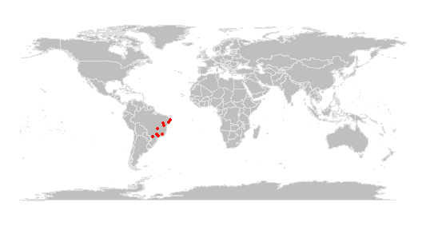

Records flagged as potentially problematic

```r
check_space %>%
  dplyr::filter(.summary == FALSE) %>% # map only records flagged as FALSE
  bdc_quickmap(
    data = .,
    lon = "decimalLongitude",
    lat = "decimalLatitude",
    col_to_map = ".summary",
    size = 0.9
  )
```

#### **Report**

Creating a report summarizing the results of all tests. The report can be automatically saved if `save_report = TRUE.`

```r
report <-
  bdc_create_report(data = check_space,
                    database_id = "database_id",
                    workflow_step = "space",
                    save_report = FALSE)

report
```

| Description | Test_name | Records_flagged | perc_number_records(*) |
| --- | --- | --- | --- |
| Identical coordinates | .equ | 0 | 0 |
| Plain zeros | .zer | 0 | 0 |
| Records around country capital centroid | .cap | 0 | 0 |
| Records around country or province centroids | .cen | 0 | 0 |
| Geographical outliers | .otl | 0 | 0 |
| Records around the GBIF headquarters | .gbf | 0 | 0 |
| Records around biodiversity institutions | .inst | 0 | 0 |
| Duplicated coordinates per species | .dpl | 0 | 0 |
| Rounded (probably imprecise) coordinates | .rou | 2 | 1.74 |
| Records within urban areas | .urb | 6 | 5.22 |

[output cut: 2 more lines]

#### **Figures**

Here we create figures (bar plots, maps, and histograms) to make the interpretation of the results of data quality tests easier. Figures can be automatically saved if `save_figures = TRUE.`

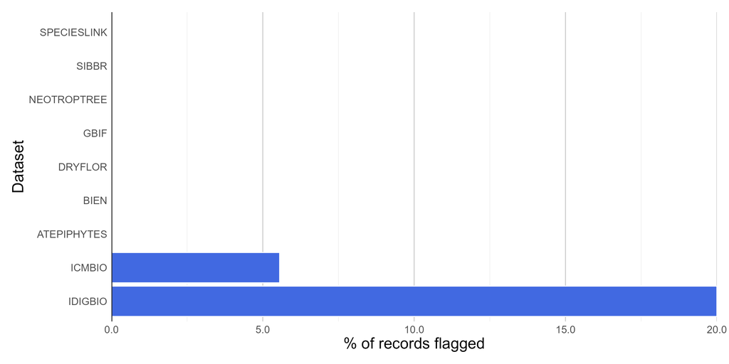

Rounded coordinates

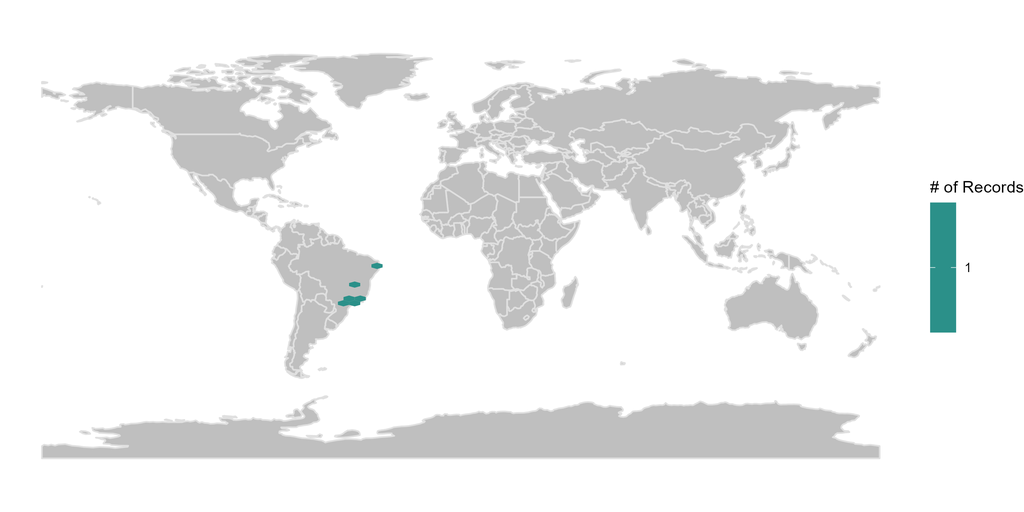

Records within urban areas

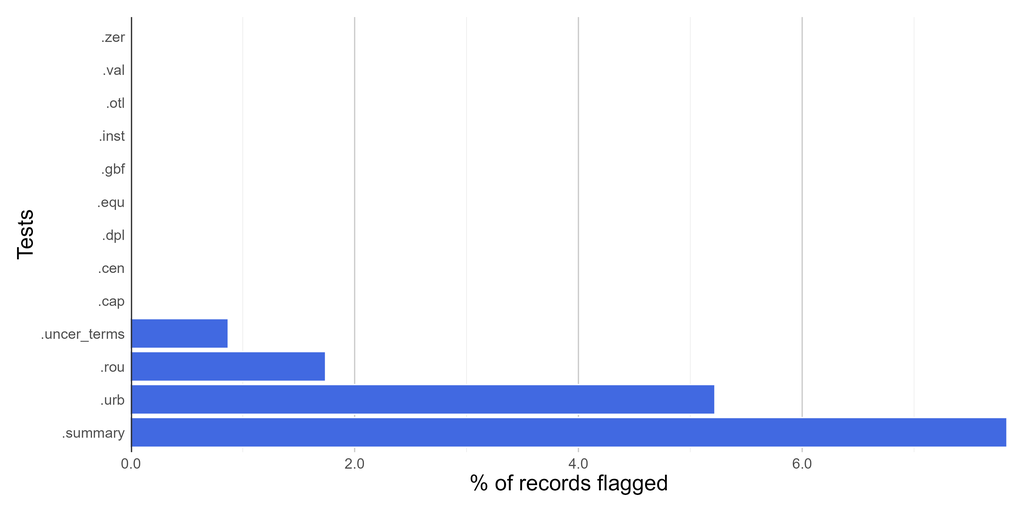

Summary of all tests

```r
figures <-
bdc_create_figures(data = check_space,
                   database_id = "database_id",
                   workflow_step = "space",
                   save_figures = TRUE)

# Check figures using
figures$.rou
```

#### **Filtering the database**

It is possible to remove flagged records (potentially problematic ones) to get a ‘clean’ database (i.e., without test columns starting with “.”). However, to ensure that all records will be evaluated in all the data quality tests (i.e., tests of the taxonomic, spatial, and temporal module of the package), potentially erroneous or suspect records will be removed in the final module of the package.

```r
# output <-
#   check_space %>%
#   dplyr::filter(.summary == TRUE) %>%
#   bdc_filter_out_flags(data = ., col_to_remove = "all")
```

#### **Saving the database**

You can use qs::qsave() instead of write_csv to save a large database in a compressed format.

```r
# use qs::qsave() to save the database in a compressed format and then qs:qread() to load the database
check_space %>%
 readr::write_csv(.,
            here::here("Output", "Intermediate", "03_space_database.csv"))
```